# Final Project (SOC 71600)

A city-level statistical analysis of lower total fertility rate (TFR) trend in South Korea

Byeong Hyeon, So

5/20/2020

### **Abstract**

**Objective**: To identify significant societal indicator of cities in South Korea that are showing higher or lower total fertility rate than statistical expectations on a set of societal variables.

**Design**: Quantitative, cross-sectional, and city-level secondary analysis of variables and indicators of South Korea. Data are analyzed using the analysis of variance (ANOVA & MANOVA) and multiple regression (multiple linear regression & logistic regression) to identify cities showing higher or lower TFR than expected outcome given societal indicators.

**Data**: The data are attained from Korean Statistical Information Service (KOSIS), the national statistical database operated by Statistics Korea. Each variable/indicator for the analysis is gathered separately, and merged as one dataset organized by cities. Majority of the data are based on 2018 government survey to align with the 2018 TFR data, except for housing status (2015) and gross regional domestic product (GRDP) (2016) which are not annually measured.

**Participants**: Cities (“Si”) in South Korea (n=84) constitute the unit of analysis for this project.

**Independent Variables**: population size, smoking rate, drinking rate, number of cultural center per 100,000 people, number of social welfare institution per 100,000 people, number of “cram school” per 1,000 people, number of pre-K school per 1,000 children (ages from 0 to 5), unemployment rate, form of housing, percentage of single household, number of marriage per 1,000, and percentage of population with higher stress level. (Binary & categorical variables are created throughout the analysis.)

**Dependent Variable(s)**: Total fertility rate (TFR: the average number of children a woman would have if she survives through her childbearing years from 15 to 49 years old), and number of marriage per 1,000 for each city in South Korea. (Binary & categorical variables are created throughout the analysis.)

### **Introduction**

The period total fertility rate (TFR) represents “the average number of children who would be born to a hypothetical cohort of women who survive to the end of their reproductive period and who bear children at each age at the rate observed during a particular period” (Preston, S. H., Heuveline, P., & Guillot, M., 2001). The Republic of Korea has maintained its reputation of having one of the lowest birthrates in the world in recent decades. Like other Asian countries such as Hong Kong, Taiwan, and Singapore, South Korea has experienced a steady decrease in population size as a result of the low fertility rate (World Population Review (WPR), 2019). Even though it is a debatable issue whether the population decline due to its lower birth rate is positive or negative for South Korea in general, it is certainly expectable that there would be a consequence of dramatic changes in social, political and economic areas following the population shrinkage. This low fertility trend has been maintained with its decreasing trend for more than 30 years in South Korea, and it had already reached below 1.00 in 2018 (Korean Statistical Information Service (KOSIS), 2019). More interestingly, Seoul, the capital city of South Korea, has experienced even much lower TFR than the average of South Korea with its own social culture and demographic characteristics (KOSIS, 2019). In 2019, the TFR in Seoul has reached below 0.7 (0.69 in the third quarter: July, August, and September) which has set the new record as “the lowest TFR in history” (Kim, S., 2019). Furthermore, statistics show that the number of newborn babies each month has been constantly decreasing for 46 months straight from December, 2015 to the present (Kim, S., 2019). Whether it is a mixed blessing or not, the country has already been seeing some substantial socio-political and economic changes as a consequence of low fertility rates (Kim, S., 2019).

To understand this social phenomenon in depth, this paper focuses on understanding underlying societal factors that are potentially associated with this lower fertily trend happening in South Korea. Even though personal decision on the birth of a child can be examined and assessed more thoroughly and accurately with involving individual-level researches and qualitative analysis, this project analyzes city-level data to grasp society-level indicators that might be explaining this low fertility trend as a matter of socio-economic and political grounds. To find out significant factors determining the low fertility rate, Comparing the cities within South Korea might not be as effective as comparing different countries of dissimilar characteristics such as different sets of social values, socio-economic status, or demographic backgrounds. However, through analyzing more uniformed and well-measured sets of data organized by the local/central governments, it would provide more reliable results which enable us to understand underlying societal patterns of current fertility trend in South Korea.

### **Descriptive Plots with City-Level Data**

Here are some descriptive visualizations representing the potential associations between different variables in our dataset. I assumed unemployment rate as a main factor for low TFR and marriage rate, but there is no distinctive linear relationship shown in the plots.

**The Relationship between Unemployment Rate and TFR & Unemployment Rate and Marriage Rate**

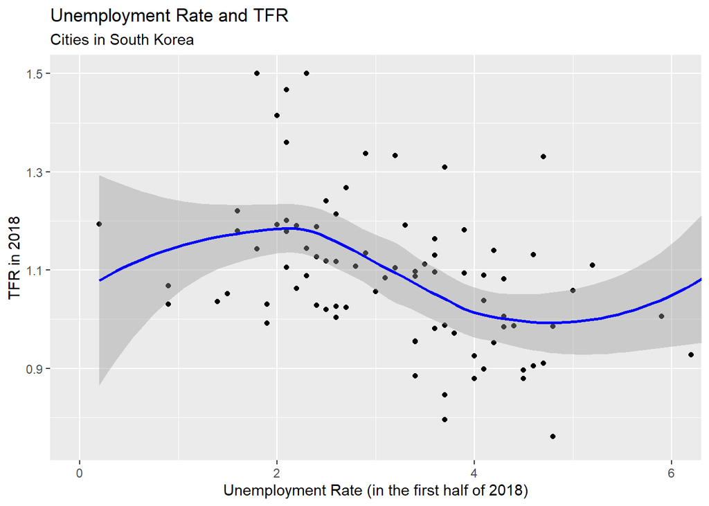

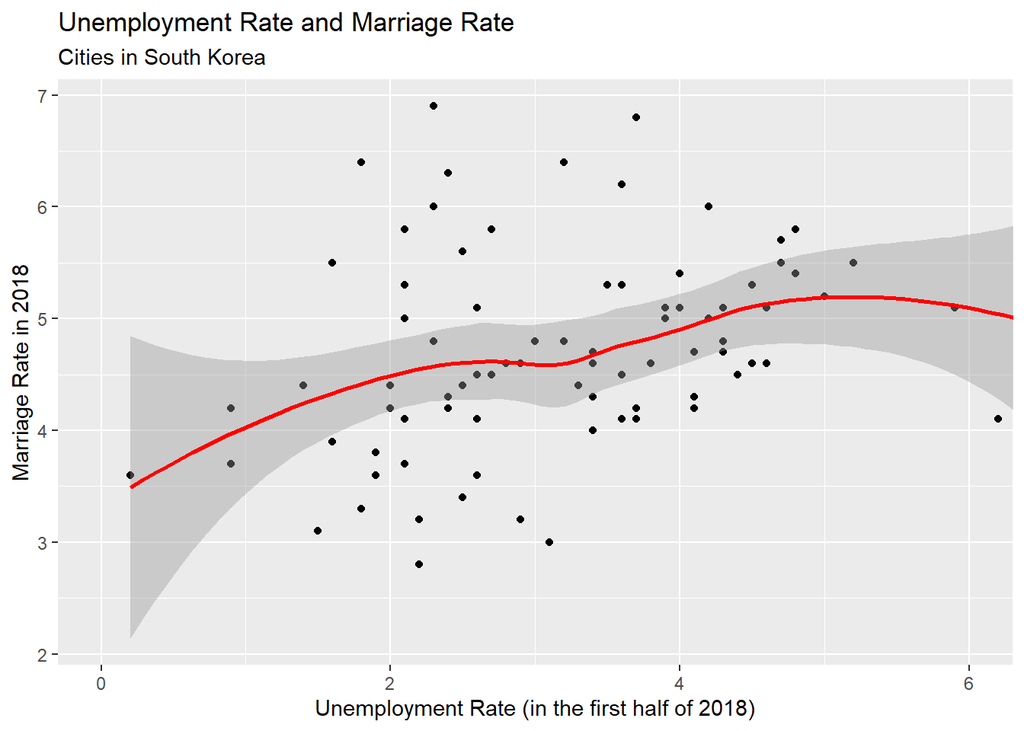

Based on the assumption of a linear relationship between TFR and marriage rate, even though there is no “distinctive” pattern of association based on given binary variables (unemployment rate, income level, stress level, and city size), the plots below indicate that there might be an underlying association as some patterns of cluster (red & blue dots) are found. I would like to explore hidden correlation/association patterns between these variables, if there is any, using statistical analysis.

**The Relationship between TFR and Marriage Rate**

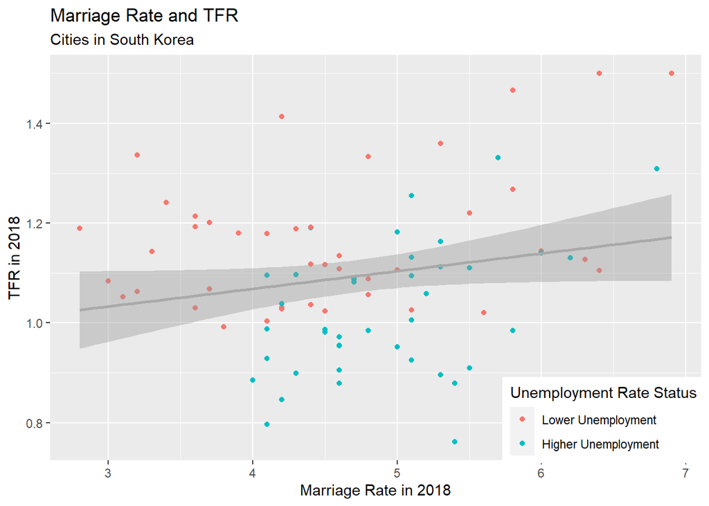

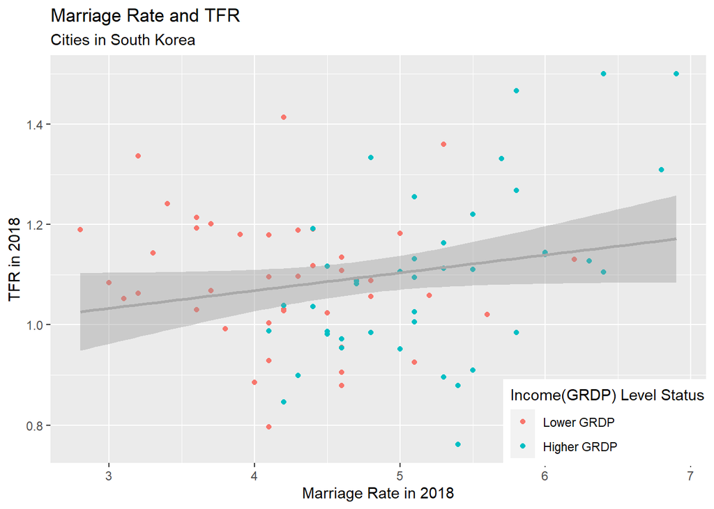

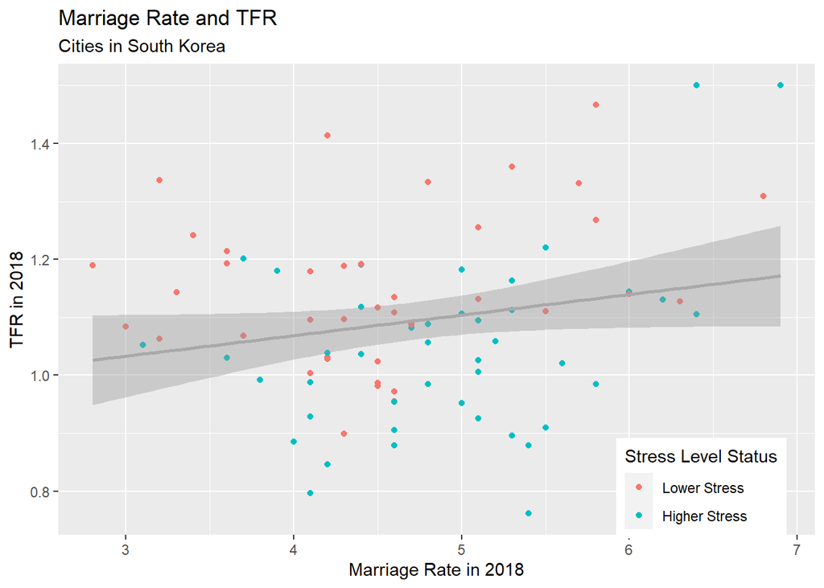

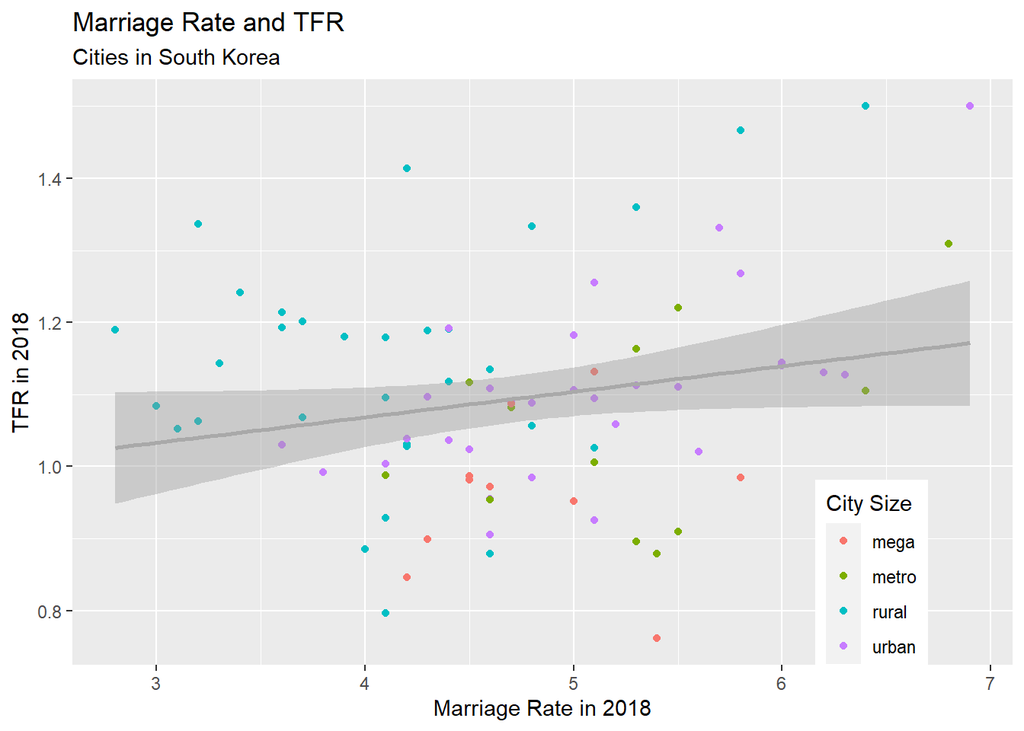

### **Statistical Analysis Results & Interpretations**

To identify significant association using these city-level data, I used analysis of variance (ANOVA), multivariate analysis of variance (MANOVA), and regression analysis (logistic regression & multiple linear regression). Before starting the analysis of variance, statistical assumptions have been assessed with relevant tests.

According to the Shapiro-Wilk test for normality, we accept the null hypothesis with P-value higher than 0.05. Both TFR (“tfr_noOL” is newly created after replacing the outlier with 95th percentile value) and Marriage Rate variables (“marriage”) are normally distributed.

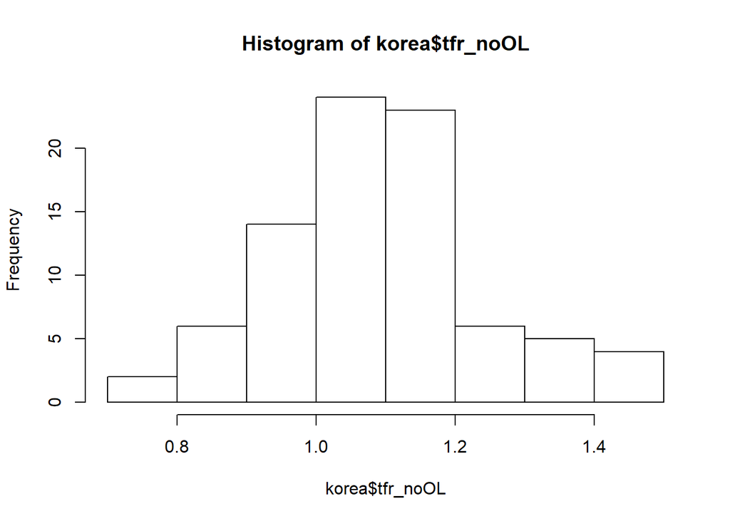

```
##
##  Shapiro-Wilk normality test
##
## data:  korea$tfr_noOL
## W = 0.97399, p-value = 0.08663
```

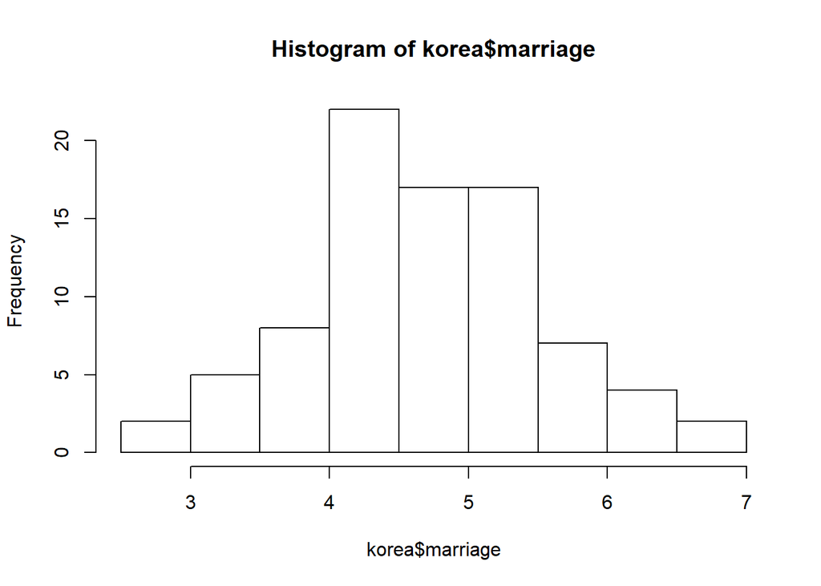

```
##
##  Shapiro-Wilk normality test
##
## data:  korea$marriage
## W = 0.98867, p-value = 0.6789
```

For the assumption of equality of variances, Levene’s test of homogeneity of variances is used. With P-values higher than 0.05 for both variables, the variances in “metro” groups are approximately equal and the assumption is met.

```
## Levene's Test for Homogeneity of Variance (center = median)
##       Df F value Pr(>F)
## group  3  1.6674 0.1806
##       80
```

```
## Levene's Test for Homogeneity of Variance (center = median)
##       Df F value Pr(>F)
## group  3  0.6132 0.6084
##       80
```

**One-way ANOVA Results**

*A. TFR and City Size*

With P-value lower than 0.05 (0.00312), we reject the null hypothesis. There is a statistically significant difference in average TFR among “metro” city groups. According to the post-hoc test,

-Rural cities (population below 200,000) have higher average TFR than mega cities(population above 1,000,000) by 0.18 (p-value = 0.002).

-Urban cities (population between 200,000 and 500,000) have higher average TFR than mega cities(population above 1,000,000) by 0.14 (p-value = 0.034).

```
##             Df Sum Sq Mean Sq F value  Pr(>F)
## metro        3 0.2966 0.09888   5.007 0.00312 **
## Residuals   80 1.5800 0.01975
## ---
## Signif. codes:  0 '***' 0.001 '**' 0.01 '*' 0.05 '.' 0.1 ' ' 1
```

```
##   Tukey multiple comparisons of means
##     95% family-wise confidence level
##
## Fit: aov(formula = tfr_noOL ~ metro, data = korea)
##
## $metro
##                    diff          lwr        upr     p adj
## metro-mega   0.08814394 -0.065780673 0.24206855 0.4407991
## rural-mega   0.18334018  0.053926977 0.31275337 0.0020703
## urban-mega   0.13722727  0.007250403 0.26720414 0.0344410
## rural-metro  0.09519624 -0.030173835 0.22056631 0.1994826
## urban-metro  0.04908333 -0.076868505 0.17503517 0.7367884
## urban-rural -0.04611290 -0.140552595 0.04832679 0.5775139
```

*B. Marriage Rate and City Size*

With P-value lower than 0.05 (9.74e-06), we reject the null hypothesis. There is a statistically significant difference in average marriage rate among “metro” city groups. According to the post-hoc test,

-Rural cities (population below 200,000) have lower average marriage rate than mega cities(population above 1,000,000) by 0.71 (p-value = 0.047).

-Rural cities (population below 200,000) have lower average marriage rate than metro cities(population between 500,000 and 1,000,000) by 1.14 (p-value = 0.0002).

-Rural cities (population below 200,000) have lower average marriage rate than urban cities (population between 200,000 and 500,000) by 0.91 (p-value = 0.00007).

```
##             Df Sum Sq Mean Sq F value   Pr(>F)
## metro        3  17.62   5.875   10.15 9.74e-06 ***
## Residuals   80  46.31   0.579
## ---
## Signif. codes:  0 '***' 0.001 '**' 0.01 '*' 0.05 '.' 0.1 ' ' 1
```

```
##   Tukey multiple comparisons of means
##     95% family-wise confidence level
##
## Fit: aov(formula = marriage ~ metro, data = korea)
##
## $metro
##                   diff        lwr          upr     p adj
## metro-mega   0.4303030 -0.4029966  1.263602653 0.5311369
## rural-mega  -0.7073314 -1.4079339 -0.006728869 0.0469532
## urban-mega   0.2036364 -0.5000177  0.907290413 0.8723943
## rural-metro -1.1376344 -1.8163487 -0.458920123 0.0001926
## urban-metro -0.2266667 -0.9085305  0.455197122 0.8191693
## urban-rural  0.9109677  0.3997008  1.422234641 0.0000684
```

**MANOVA Results**

*A. One-Way MANOVA*

The One-way MANOVA is performed to test the within and between group variations using the combination of two dependant variables (TFR and Marriage Rate), and to see whether the independent variables (“metro”, “income_bin”, “stress_bin” and “unemp_bin”) are significantly related to the linear combination of the TFR and marriage rate.

According to the test result, all four independent variables are significantly related to the linear combination of the TFR and marriage rate. Eta-squared coefficient result indicates that the city’s income (GRDP) level is having the largest impact on understanding the variations in this TFR + marriage rate followed by stress level, city size, and unemployment rate.

```
##            Df  Pillai approx F num Df den Df    Pr(>F)
## metro       3 0.60698  11.1838      6    154 2.420e-10 ***
## income_bin  1 0.27033  14.0785      2     76 6.292e-06 ***
## unemp_bin   1 0.17135   7.8577      2     76 0.0007909 ***
## stress_bin  1 0.18453   8.5990      2     76 0.0004300 ***
## Residuals  77
## ---
## Signif. codes:  0 '***' 0.001 '**' 0.01 '*' 0.05 '.' 0.1 ' ' 1
```

```
##                eta^2
## metro      0.1632185
## income_bin 0.2638431
## unemp_bin  0.1141279
## stress_bin 0.1845313
```

*B. Two-Way MANOVA & Three-Way MANOVA*

If we add in the two-way interactions, it appears that the interaction of unemployment rate (binary) and income (GRDP) level (binary) also has a significant impact on understanding the variations in the combination of TFR and marriage rate.  
However, there is no added benefit when we add three-way interactions into our model. Still, income (GRDP) level appears to be the strongest effect in the model, followed by stress level, city size, unemployment rate, and the interaction of income and unemployment rate respectively.

```
##                       Df  Pillai approx F num Df den Df    Pr(>F)
## metro                  3 0.62906  11.3183      6    148 2.181e-10 ***
## income_bin             1 0.28678  14.6762      2     73 4.392e-06 ***
## unemp_bin              1 0.17532   7.7597      2     73 0.0008798 ***
## stress_bin             1 0.18966   8.5429      2     73 0.0004638 ***
## income_bin:unemp_bin   1 0.09101   3.6546      2     73 0.0307150 *
## income_bin:stress_bin  1 0.01247   0.4609      2     73 0.6325600
## unemp_bin:stress_bin   1 0.02330   0.8707      2     73 0.4229579
## Residuals             74
## ---
## Signif. codes:  0 '***' 0.001 '**' 0.01 '*' 0.05 '.' 0.1 ' ' 1
```

```
##                             eta^2
## metro                 0.149280337
## income_bin            0.267974540
## unemp_bin             0.116551444
## stress_bin            0.171313829
## income_bin:unemp_bin  0.079396183
## income_bin:stress_bin 0.004772714
## unemp_bin:stress_bin  0.023299151
```

```
##                                 Df  Pillai approx F num Df den Df    Pr(>F)
## metro                            3 0.63314  11.2714      6    146 2.524e-10 ***
## income_bin                       1 0.29203  14.8496      2     72 3.986e-06 ***
## unemp_bin                        1 0.17532   7.6534      2     72 0.0009688 ***
## stress_bin                       1 0.18976   8.4312      2     72 0.0005130 ***
## income_bin:unemp_bin             1 0.09312   3.6966      2     72 0.0296325 *
## income_bin:stress_bin            1 0.01279   0.4664      2     72 0.6291379
## unemp_bin:stress_bin             1 0.02360   0.8700      2     72 0.4233033
## income_bin:unemp_bin:stress_bin  1 0.02862   1.0609      2     72 0.3515049
## Residuals                       73
## ---
## Signif. codes:  0 '***' 0.001 '**' 0.01 '*' 0.05 '.' 0.1 ' ' 1
```

```
##                                       eta^2
## metro                           0.156231775
## income_bin                      0.273174816
## unemp_bin                       0.116576321
## stress_bin                      0.171324839
## income_bin:unemp_bin            0.081177234
## income_bin:stress_bin           0.004912624
## unemp_bin:stress_bin            0.023596759
## income_bin:unemp_bin:stress_bin 0.028624865
```

**Regression Analysis Results**

*A. Binary Logistic Regression*

Controlling for all other variables in the model (statistically significant results only),

-Higher stress level is associated with 0.15 odds of having higher TFR (85% less likely).

-Each unit increase in marriage rate is associated with 3.32 odds of having higher TFR.

```
##
## Call:
## glm(formula = tfr_bin ~ metro_bin + stress_bin + prek_bin + cram_bin +
##     marriage, family = "binomial", data = korea)
##
## Deviance Residuals:
##      Min        1Q    Median        3Q       Max
## -2.14554  -0.83367   0.00295   0.81217   1.77181
##
## Coefficients:
##                   Estimate Std. Error z value Pr(>|z|)
## (Intercept)        -5.9747     2.0276  -2.947  0.00321 **
## metro_binnonmetro   2.3109     0.7376   3.133  0.00173 **
## stress_bin1        -1.8630     0.6104  -3.052  0.00227 **
## prek_bin1          -1.0302     0.5600  -1.840  0.06582 .
## cram_bin1           0.3437     0.5850   0.588  0.55685
## marriage            1.1992     0.4028   2.977  0.00291 **
## ---
## Signif. codes:  0 '***' 0.001 '**' 0.01 '*' 0.05 '.' 0.1 ' ' 1
##
## (Dispersion parameter for binomial family taken to be 1)
##
##     Null deviance: 116.449  on 83  degrees of freedom
## Residual deviance:  83.951  on 78  degrees of freedom
## AIC: 95.951
##
## Number of Fisher Scoring iterations: 5
```

```
## Wald test:
## ----------
##
## Chi-squared test:
## X2 = 19.3, df = 5, P(> X2) = 0.0017
```

```
##       (Intercept) metro_binnonmetro       stress_bin1         prek_bin1
##       0.002542197      10.083769465       0.155206993       0.356920124
##         cram_bin1          marriage
##       1.410187138       3.317432621
```

*B. Ordered Logistic Regression*

According to the coeftest(ord_tfr) result, “metro”, “stress”, “unemployment rate”, and “marriage rate” are significantly associated with having a higher or lower TFR category (“Lowest”: 1, “Average”: 2, and “Above Average”: 3).

Controlling for all other variables included in the model (statistically significant results only),

-A city categorized as having higher unemployment rate is 92% less likely to be in a higher category of TFR relative to a city with a lower unemployment rate.

```
## Call:
## polr(formula = tfr_cat ~ metro_bin + stress_bin + prek_bin +
##     unemp_bin + cram_bin + marriage_bin + smoking_bin, data = korea,
##     Hess = T)
##
## Coefficients:
##                     Value Std. Error t value
## metro_binnonmetro  1.4918     0.6698  2.2272
## stress_bin1       -1.4126     0.5575 -2.5337
## prek_bin1         -1.1061     0.5166 -2.1412
## unemp_bin1        -2.5272     0.6914 -3.6550
## cram_bin1          0.4941     0.5698  0.8671
## marriage_bin1      1.5945     0.5660  2.8171
## smoking_bin        0.2606     0.5380  0.4843
##
## Intercepts:
##     Value   Std. Error t value
## 1|2 -1.9278  0.9626    -2.0026
## 2|3  2.2818  0.9175     2.4871
##
## Residual Deviance: 116.5521
## AIC: 134.5521
```

```
##
## z test of coefficients:
##
##                   Estimate Std. Error z value  Pr(>|z|)
## metro_binnonmetro  1.49181    0.66980  2.2272 0.0259311 *
## stress_bin1       -1.41260    0.55752 -2.5337 0.0112858 *
## prek_bin1         -1.10607    0.51656 -2.1412 0.0322571 *
## unemp_bin1        -2.52717    0.69143 -3.6550 0.0002572 ***
## cram_bin1          0.49409    0.56981  0.8671 0.3858792
## marriage_bin1      1.59455    0.56602  2.8171 0.0048455 **
## smoking_bin        0.26057    0.53802  0.4843 0.6281664
## 1|2               -1.92781    0.96264 -2.0026 0.0452178 *
## 2|3                2.28180    0.91747  2.4871 0.0128802 *
## ---
## Signif. codes:  0 '***' 0.001 '**' 0.01 '*' 0.05 '.' 0.1 ' ' 1
```

```
## metro_binnonmetro       stress_bin1         prek_bin1        unemp_bin1
##        4.44512921        0.24350858        0.33085627        0.07988464
##         cram_bin1     marriage_bin1       smoking_bin
##        1.63900087        4.92609196        1.29766902
```

*C. Multiple Linear Regression*

To perform the multiple linear regression analysis and find the best-fitting model to explain the current fertility trend in South Korea, certain statistical assumptions have to be met. Here are some statistical testing results to check the assumptions.

A few outliers are found based on their “standardized residuals” which are larger than 3 (absolute value).

```
##
## Call:
## lm(formula = tfr_noOL ~ smoking + priv_school + lease + rent +
##     grdp + pop + stress + marriage + pre_k, data = korea)
##
## Residuals:
##      Min       1Q   Median       3Q      Max
## -0.16158 -0.04532 -0.01030  0.03509  0.23717
##
## Coefficients:
##               Estimate Std. Error t value Pr(>|t|)
## (Intercept)  1.721e+00  1.432e-01  12.015  < 2e-16 ***
## smoking     -1.759e-02  4.905e-03  -3.587 0.000598 ***
## priv_school -8.394e-02  2.746e-02  -3.057 0.003113 **
## lease       -1.356e-02  2.005e-03  -6.762 2.73e-09 ***
## rent        -6.561e-03  2.489e-03  -2.636 0.010215 *
## grdp         2.703e-06  1.208e-06   2.238 0.028253 *
## pop         -1.051e-07  3.337e-08  -3.151 0.002350 **
## stress      -4.220e-03  2.684e-03  -1.572 0.120181
## marriage     1.032e-01  1.465e-02   7.043 8.17e-10 ***
## pre_k       -8.669e-03  3.883e-03  -2.233 0.028603 *
## ---
## Signif. codes:  0 '***' 0.001 '**' 0.01 '*' 0.05 '.' 0.1 ' ' 1
##
## Residual standard error: 0.08403 on 74 degrees of freedom
## Multiple R-squared:  0.7216, Adjusted R-squared:  0.6877
## F-statistic: 21.31 on 9 and 74 DF,  p-value: < 2.2e-16
```

According to the Durbin-Watson test measuring the autocorrelation in the residuals, with P-value higher than 0.05, we accept the null hypothesis. There is no autucorrelation detected in this model.

```
##  lag Autocorrelation D-W Statistic p-value
##    1     0.006338235      1.982831   0.736
##  Alternative hypothesis: rho != 0
```

The plot(fitted vs residuals) indicates that there might be a violation of homoskedasticity of residuals with a few outliers. The Shapiro test result also indicates that the residuals are not normally distributed by rejecting the null hypothesis (P-value lower than 0.05).

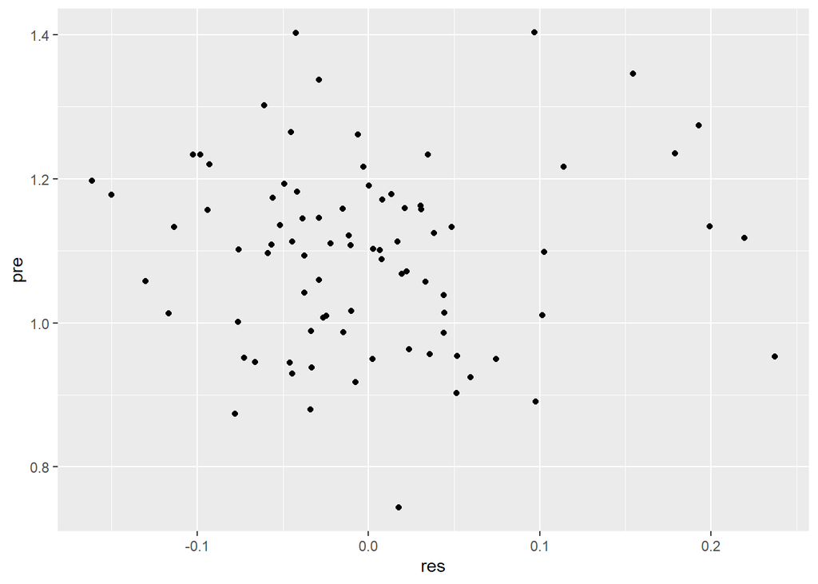

```
##
##  Shapiro-Wilk normality test
##
## data:  res
## W = 0.94644, p-value = 0.001595
```

The assumption regards to the multicollinearity is tested using variance inflation factor (VIF). There is a multicollinearity going on with population and income level (GRDP) showing VIF scores bigger than 10.

```
##           Variables       VIF
## 1     korea.smoking  1.680238
## 2 korea.priv_school  1.353947
## 3       korea.lease  2.156433
## 4        korea.rent  1.788467
## 5        korea.grdp 17.260056
## 6       korea.pre_k  1.268595
## 7      korea.stress  1.174610
## 8         korea.pop 18.026609
## 9    korea.marriage  1.942610
```

To deal with the violation(s) detected, I decided to get rid of outliers (four cities) based on the standardized residuals for the given regression model. Moreover, I adjusted the outlier value in population variable (specifically, Seoul’s population) to reduce the influence to the model and created a new variable, “pop_noOL”. I got rid of the income level (GRDP) variable as well to deal with the multicollinearity issue (between population size and GRDP indicators) detected based on the VIF scores.

The model regresses the total fertility rate on the percentage of smoking population, the number of cram school per 100,000, the percentage of people living in rented or leased place, population, the number of marriage per 1,000, and the number of Pre-K school per 1,000 children. About 80% (Adjusted R-Squared = 0.8016) of variation in city-level TFR is explained by these independent variables.

Controlling for all other variables in the model (statistically significant results only),

-A one percent increase in the smoking population of the city is associated with the decrease in the TFR by 0.014.

-A unit increase in the city’s cram school is associated with the decrease in the TFR by 0.0556.

-A one percent increase in the percentage of people living in a leased place is associated with the decrease in the TFR by 0.016.

-A one percent increase in the percentage of people living in a rented place is associated with the decrease in the TFR by 0.0059.

-A unit increase in the number of marriage per 1,000 is associated with the increase in the TFR by 0.13.

-A unit increase in the number of Pre-K school per 1,000 children is associated with the decrease in the TFR by 0.011.

```
##
## Call:
## lm(formula = tfr_noOL ~ smoking + priv_school + lease + rent +
##     pop_noOL + marriage + pre_k, data = korea_noOL)
##
## Residuals:
##       Min        1Q    Median        3Q       Max
## -0.157370 -0.041890  0.003182  0.033731  0.176005
##
## Coefficients:
##               Estimate Std. Error t value Pr(>|t|)
## (Intercept)  1.408e+00  1.079e-01  13.054  < 2e-16 ***
## smoking     -1.413e-02  3.744e-03  -3.774 0.000328 ***
## priv_school -5.557e-02  2.130e-02  -2.609 0.011039 *
## lease       -1.566e-02  1.509e-03 -10.378 6.01e-16 ***
## rent        -5.857e-03  1.878e-03  -3.118 0.002614 **
## pop_noOL    -6.143e-08  1.220e-08  -5.036 3.39e-06 ***
## marriage     1.295e-01  1.084e-02  11.953  < 2e-16 ***
## pre_k       -1.094e-02  3.069e-03  -3.566 0.000649 ***
## ---
## Signif. codes:  0 '***' 0.001 '**' 0.01 '*' 0.05 '.' 0.1 ' ' 1
##
## Residual standard error: 0.06414 on 72 degrees of freedom
## Multiple R-squared:  0.8192, Adjusted R-squared:  0.8016
## F-statistic: 46.59 on 7 and 72 DF,  p-value: < 2.2e-16
```

### **Bibliography**

Korean Statistical Information Service (KOSIS) (2019). Retrieved from http://kosis.kr/eng/statisticsList/statisticsListIndex.do?menuId=M_01_01&vwcd=MT_ETITLE&parmTabId=M_01_01

Kim, S. (2019). Seoul’s total fertility rate 0.69 “the state of population crisis”. Chosun Daily News & Chosun.com, Chosun Biz, Inc. Retrieved from https://news.chosun.com/site/data/html_dir/2019/11/28/2019112800259.html

Preston, S. H., Heuveline, P. & Guillot, M. (2001), Demography: measuring and modeling population processes. Malden, MA: Blackwell Publishing

World Population Review (WPR) (2019). South Korea population 2019. Retrieved from http://worldpopulationreview.com/countries/south-korea-population/